# POLS 2998W

The United States Congress, Process and Policy-Making

Lecture 11 | The House Floor

## Plan for Today

- Discuss Assorted House Floor Issues
- Discuss The House Floor
- Discuss Voting on the House Floor

## The House Floor

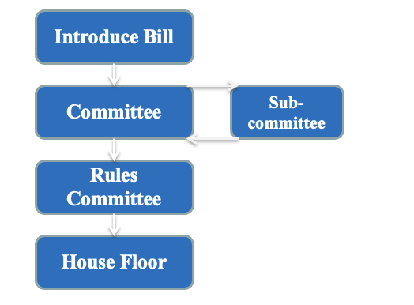

## The House Floor

- First vote may be to order the previous question motion on the Rule, followed by a vote on the Rule itself
- Debate here is structured by the rule
  - Generally, the floor is empty and the outcome is pre-determined
- Note: Not all votes are recorded!

## The House Floor

- This is often followed by debate on the bill, votes on any amendments (may not be recorded), a motion to recommit with instructions, potential votes on points of order and a vote on the bill
- What influences member votes?
  - Reelection, policy goals, reelection, party loyalty, reelection
    - Priorities are often as important as policy goals
- Minority input in the House?

## House Floor: Motion to Recommit

- Under House rules, a motion to recommit the bill, either with or without instructions, to the committee that originally reported it is almost always in order
- A motion to recommit with instructions that the committee report forthwith ensures the bill does not leave the floor and essentially provides the minority with an opportunity to offer an amendment of its choosing
- A straight motion to recommit sends the bill back the parent committee essentially killing the bill
- The motion to recommit can only be offered by an opponent of a bill at the conclusion of debate
  - The motion is the prerogative of the minority party and is not provided in advance to members
- The motion has plagued Democratic leadership, who lost six pivotal motion to recommit votes in 18 months of controlling the 115th House
  - In the previous eight years, Republican majorities were never defeated on a motion to recommit

## Enacting Clause and Amendments

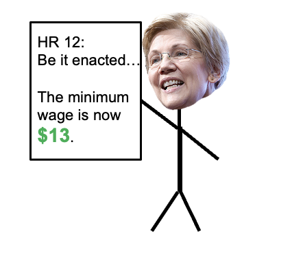

- The first clause of a bill is the “enacting clause.”
- “Striking the enacting clause” is an attempt to kill the legislation
- “Striking all after the enacting clause” means someone is trying replace the entire text of the legislation
- This is quite common when two chambers are trying to pass the same bill in order to go to a conference committee

## House Floor: Typical Vote Sequence

- Rule is brought to the floor and debated
  - Vote - Previous Question Motion on a Special Rule
  - Vote - Vote on the Special Rule
- Amendments, should the rule allow them, are debated and voted on
  - Vote - Motion to Recommit the Bill (Should the Rule Allow it)
  - Vote – Passage of the Bill

## Roll Call Voting

- Not the default vote mechanism in Congress
- Most voting in Congress is completed via voice vote
- Recorded votes must be requested by a member and the request must be supported by one-fifth of present members (Article I, Section 5, Clause 3)
  - Some debate over this at the Constitutional Convention
  - Several delegates supported dropping the quorum threshold, others opposed the yeas and nays altogether
    - After several failed and one successful amendment, the yeas and nays clause was adopted
- Four primary vote types in Congress: (1) voice vote; (2) division vote; (3) teller vote; (4) roll call vote

## Origins of Recorded Votes

- The practice of publicizing how legislators voted occurred on rare occasion in 17th and 18th century Great Britain
- The first known instance of this occurred in 1641, after a vote ordering the execution of Thomas Wentworth, the 1st Earl of Strafford
- The names of those who voted against the bill of attainder were publicized as “betrayers of their country (Luce 1922, 355).”
  - The vote passed and Strafford was eventually beheaded

## Voice Vote

- The default voting mechanism in Congress is the voice vote
- During a voice vote, the chair will put forward two questions:
  - “All in favor say: Yea”
  - “All opposed say: Nay”
- The job of tallying the votes in such a situation falls to the chair, and his or her count cannot be appealed
- While members may make their opinions clearly known, voice votes produce no record of individual positions on a given bill

## Division Vote

- A division vote can be requested by any member
- Once requested, members rise if they take the affirmative on a question and they are then counted by the chair
- This process is repeated for those in opposition
- Division votes are not recorded and – like with voice votes – the chair’s count of the votes cannot be appealed

## Teller Vote

- A teller vote is a vote in which members of Congress pass between two tellers, who write down the votes of each member, along with their names
- Teller voting is restricted to the House of Representatives and is used infrequently in the modern era
- While it is likely to yield more accurate vote totals than either voice or division votes, it is similar to these in that it also does not produce a record of how members cast their votes

## Roll Call Votes

- To receive a roll call vote in either chamber a member needs a second of “one-fifth of those present.”
- In the House of the Representatives, once a sufficient second is voiced a roll call vote is taken
  - This voting has largely been done electronically since 1972
    - When the vote is called, members insert a personalized voting card into a station on the House floor and press either “Present”, “Yea”, or “Nay”
    - Members’ votes are then displayed on panels throughout the chamber
- While the speaker does have authority to extend votes, few last longer than the 15 minute requirement
- In the Senate, once the yeas and nays are ordered, the clerk begins to call the names of each senator alphabetically
  - The senator then has, generally, 15 minutes to respond to his or her name

## Final Thoughts

- Questions? Concerns? Angry Rants?
- Exam
- Ideological Scaling
- House Rule Choice